Solve practical problems with Data Science and Technology

# Forcing Regression Coefficients in R - Part I

7 Feb, 2020 · by Alvaro Aguado · Read in about 26 min · (5449 Words)  
Regression R Easy Marketing Mix

# Forcing Regression Coefficients in R - Part I

Alvaro Aguado

2020-02-07

### **Question**:

I’m working on a regression model and I need to force the regression coefficients to be positive. How can I accomplish this in R?

### **Solution**:

For linear model regression model with restricted coefficients you have 3 options: Linear with nls, Bayes with brms and Lasso. Here we will look at `Linear Model with nls`

The function lm does not provide a way to restrict coefficients. Instead we can use the function nls under the algorithm port. This allow us to provide start for the coefficients, as well as upper and lower boundaries.

In order to define the coefficients create arbitrary coefficient names and define them just like I did below. I picked “a” to be my intercept and “b1”,“b2” and “b3” to be my coefficients for the individual variables

```r
# Load libraries
require(tidyverse) #manipulate data
require(knitr) # See Table

# Use formula nls instead of lm and select algorithm port
fit1 <- nls(formula =  Sepal.Length ~ a + b1*Sepal.Width +  b2*Petal.Length + b3*Petal.Width,
    data = iris,
    start = list(a = 0,b1 = 0.0,b2 = 0, b3 = 0),
    lower = c(a = 0,b1 = 0,b2 = 0, b3 = 0),
    upper = c(a = Inf,b1 = Inf,b2 = Inf, b3 = Inf),
    algorithm = "port")

# We see that the coefficients are equal or greater than 0
c.fit1 <- data.frame(t(coef(fit1)))
colnames(c.fit1) <- c("(Intercept)",colnames(iris)[2:4])
knitr::kable(c.fit1, caption = "Forced Positive Coefficients")
```

Forced Positive Coefficients

| (Intercept) | Sepal.Width | Petal.Length | Petal.Width |
| --- | --- | --- | --- |
| 2.24914 | 0.5955247 | 0.47192 | 0 |

**That’s all**  
* For Solution with Bayes  
* For Solution with Lasso

**Want more detail?** *Then keep reading…*

### Business Applications:

`Marketing Mix`,`Price Elasticity`

In several situations, like building a marketing mix model, I found myself with variables that have to be included in a model but the coefficient ended up with the opposite sign as wanted. It’s very important in these cases to address if there are any other data issues before forcing a coefficient, since this will not make the model optimal from an OLS (Ordinary Least Squares) perspective.

For example, I had cases in which Marketing Tactics such as TV was providing negative effect in sales. While this could be true, it is uncommon to see TV ads that have negative effect in the market. A good remedy is to provide positive priors and regress using bayes approach. That could help the algorithm find I new local minima. You can find such positive priors from correlations between TV and Sales using past data prior to the model, or manually providing industry averages.

Another case is when calculating Price Elasticity. We might find that, as price increases so does sales volume. And again this could be again true if there’s scarcity of the product, or if higher price makes the product look more attractive to consumers. Again, I found myself in the situation where price elasticity did not make sense from a business perspective.

However, this was because I had relatively low number of data points to make my estimation. When prices are very concentrated in a small range, it is very hard to find the actual slope of the regression. To solve this, I first recommend to ask for more data, and if this is not possible and it’s absolutely necessary to provide an answer then I turn to ‘Shrinkage methods’ like lasso.

### Detailed Example

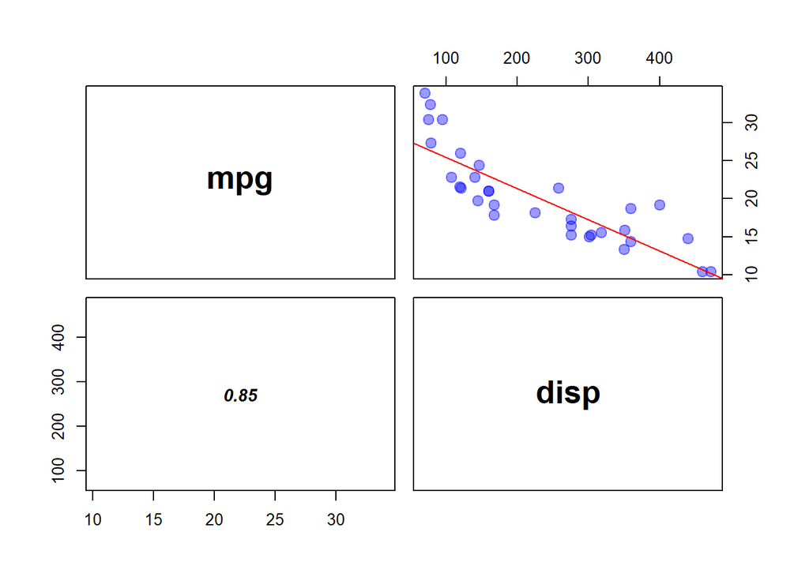

```r
# Libraries
require(tidyverse) #Manipulate data
require(DT)        #Visualize data in tables

# Function to visuzalize regression line on plot
reg <- function(x, y, col) abline(lm(y ~ x), col = col)

# Aestethics for the Pairs Plot
panel.lm =  function(x, y, col = par("col"), bg = NA, pch = par("pch"),
    cex = 1, col.smooth = "red", span = 2/3, iter = 3, ...)  {
    points(x, y, pch = pch, col = col, bg = bg, cex = cex)
    ok <- is.finite(x) & is.finite(y)
    if (any(ok)) reg(x[ok], y[ok], col.smooth)
}

# Other Aesthetics, labels and others
panel.cor <- function(x, y, digits = 2, prefix = "", cex.cor, ...)
{
 usr <- par("usr"); on.exit(par(usr))
 par(usr = c(0, 1, 0, 1))
 r <- abs(cor(x, y))
 txt <- format(c(r, 0.123456789), digits = digits)[1]
 txt <- paste0(prefix, txt)
 text(0.5, 0.5, txt, cex = 1.1, font = 4)
}

# Variable MPG and Disp show negative correlation
pairs(mtcars[c(1,3)], panel = panel.lm,
    cex = 1.5, pch = 19, col = adjustcolor(4, .4), cex.labels = 2,
    font.labels = 2, lower.panel = panel.cor)
```

```r
# However when we regress all variables disp has positive slope
lm(mpg ~ ., data = mtcars) %>%
  broom::tidy() %>%
  select(1,2) %>%
  mutate(estimate = round(estimate,4)) %>%
  knitr::kable(caption = "OLS Regression Coefficients for dependent variable MPG")
```

OLS Regression Coefficients for dependent variable MPG

| term | estimate |
| --- | --- |
| (Intercept) | 12.3034 |
| cyl | -0.1114 |
| disp | 0.0133 |
| hp | -0.0215 |
| drat | 0.7871 |
| wt | -3.7153 |
| qsec | 0.8210 |
| vs | 0.3178 |
| am | 2.5202 |
| gear | 0.6554 |
| carb | -0.1994 |

Now let’s force the coefficients to be positive for disp

```r
# Create formula for all coefficients
b_part <- paste0("b",1:(ncol(mtcars) - 1),"*", colnames(mtcars)[-1],
                 collapse = " + ")
formula <- paste0(colnames(mtcars)[1]," ~ a + ", b_part)

# Create List for the restrictions
ab_list <- c("a",paste0("b",1:(ncol(mtcars) - 1)))
start <- rep(list(0),ncol(mtcars))
names(start) <- ab_list
lower <- rep(list(0),ncol(mtcars))
names(lower) <- ab_list
upper <- rep(list(Inf),ncol(mtcars))
names(upper) <- ab_list

# Run the linear Regression with all the restrictions
nls(formula =  formula,
    data = mtcars,
    start = start,
    lower = lower,
    upper = upper,
    algorithm = "port") -> fit3
  fit3 %>%
  broom::tidy() %>%
  select(1,2) %>%
  mutate(term = c("(Intercept)",colnames(mtcars)[-1]),
         estimate_restricted = estimate) %>%
  select(term,estimate_restricted) -> tidy_fit3

lm(mpg ~ ., data = mtcars) -> fit4
fit4 %>%
  broom::tidy() %>%
  select(1,2) %>%
  mutate(estimate_original = estimate) %>%
  select(term,estimate_original) %>%
  inner_join(tidy_fit3, by = "term") -> tidy_fit3

knitr::kable(tidy_fit3, caption = "Linear Regression Coefficients for dependent variable MPG: OLS vs. Forced Coefficient")
```

Linear Regression Coefficients for dependent variable MPG: OLS vs. Forced Coefficient

| term | estimate_original | estimate_restricted |
| --- | --- | --- |
| (Intercept) | 12.3033742 | 0.0000000 |
| cyl | -0.1114405 | 0.0000000 |
| disp | 0.0133352 | 0.0000000 |
| hp | -0.0214821 | 0.0000000 |
| drat | 0.7871110 | 1.2139178 |
| wt | -3.7153039 | 0.0000000 |
| qsec | 0.8210407 | 0.6317301 |
| vs | 0.3177628 | 4.6582898 |
| am | 2.5202269 | 6.0007956 |
| gear | 0.6554130 | 0.0000000 |
| carb | -0.1994193 | 0.0000000 |

So now the question is how much worse is this new model.

If we compare residuals for each model original OLS regression had 12.1447 whereas the restricted model 17.6378.

So clearly the new model is worse. We must keep in mind that this is an extreme case, since we have forced everything to be positive. We should carefully pick what variables should be restricted and which ones shouldn’t.